# Red Wine analysis by Shweta P

```
## 'data.frame':    1599 obs. of  13 variables:
##  $ X                   : int  1 2 3 4 5 6 7 8 9 10 ...
##  $ fixed.acidity       : num  7.4 7.8 7.8 11.2 7.4 7.4 7.9 7.3 7.8 7.5 ...
##  $ volatile.acidity    : num  0.7 0.88 0.76 0.28 0.7 0.66 0.6 0.65 0.58 0.5 ...
##  $ citric.acid         : num  0 0 0.04 0.56 0 0 0.06 0 0.02 0.36 ...
##  $ residual.sugar      : num  1.9 2.6 2.3 1.9 1.9 1.8 1.6 1.2 2 6.1 ...
##  $ chlorides           : num  0.076 0.098 0.092 0.075 0.076 0.075 0.069 0.065 0.073 0.071 ...
##  $ free.sulfur.dioxide : num  11 25 15 17 11 13 15 15 9 17 ...
##  $ total.sulfur.dioxide: num  34 67 54 60 34 40 59 21 18 102 ...
##  $ density             : num  0.998 0.997 0.997 0.998 0.998 ...
##  $ pH                  : num  3.51 3.2 3.26 3.16 3.51 3.51 3.3 3.39 3.36 3.35 ...
##  $ sulphates           : num  0.56 0.68 0.65 0.58 0.56 0.56 0.46 0.47 0.57 0.8 ...
##  $ alcohol             : num  9.4 9.8 9.8 9.8 9.4 9.4 9.4 10 9.5 10.5 ...
##  $ quality             : int  5 5 5 6 5 5 5 7 7 5 ...
```

```
##        X          fixed.acidity   volatile.acidity  citric.acid
##  Min.   :   1.0   Min.   : 4.60   Min.   :0.1200   Min.   :0.000
##  1st Qu.: 400.5   1st Qu.: 7.10   1st Qu.:0.3900   1st Qu.:0.090
##  Median : 800.0   Median : 7.90   Median :0.5200   Median :0.260
##  Mean   : 800.0   Mean   : 8.32   Mean   :0.5278   Mean   :0.271
##  3rd Qu.:1199.5   3rd Qu.: 9.20   3rd Qu.:0.6400   3rd Qu.:0.420
##  Max.   :1599.0   Max.   :15.90   Max.   :1.5800   Max.   :1.000
##  residual.sugar     chlorides       free.sulfur.dioxide
##  Min.   : 0.900   Min.   :0.01200   Min.   : 1.00
##  1st Qu.: 1.900   1st Qu.:0.07000   1st Qu.: 7.00
##  Median : 2.200   Median :0.07900   Median :14.00
##  Mean   : 2.539   Mean   :0.08747   Mean   :15.87
##  3rd Qu.: 2.600   3rd Qu.:0.09000   3rd Qu.:21.00
##  Max.   :15.500   Max.   :0.61100   Max.   :72.00
##  total.sulfur.dioxide    density             pH          sulphates
##  Min.   :  6.00       Min.   :0.9901   Min.   :2.740   Min.   :0.3300
##  1st Qu.: 22.00       1st Qu.:0.9956   1st Qu.:3.210   1st Qu.:0.5500
##  Median : 38.00       Median :0.9968   Median :3.310   Median :0.6200
##  Mean   : 46.47       Mean   :0.9967   Mean   :3.311   Mean   :0.6581
##  3rd Qu.: 62.00       3rd Qu.:0.9978   3rd Qu.:3.400   3rd Qu.:0.7300
##  Max.   :289.00       Max.   :1.0037   Max.   :4.010   Max.   :2.0000
##     alcohol         quality
##  Min.   : 8.40   Min.   :3.000
##  1st Qu.: 9.50   1st Qu.:5.000
##  Median :10.20   Median :6.000
##  Mean   :10.42   Mean   :5.636
##  3rd Qu.:11.10   3rd Qu.:6.000
##  Max.   :14.90   Max.   :8.000
```

General Information:

Here I will be analysing the Red Wine dataset, using R for the quality of the wine depending on the alcohol and the acid contents along with other chemicals.

```
##    Min. 1st Qu.  Median    Mean 3rd Qu.    Max.
##   3.000   5.000   6.000   5.636   6.000   8.000
```

```
##    Min. 1st Qu.  Median    Mean 3rd Qu.    Max.
##   3.000   5.000   6.000   5.636   6.000   8.000
```

```
##
##   3   4   5   6   7   8
##  10  53 681 638 199  18
```

```
##  Ord.factor w/ 6 levels "3"<"4"<"5"<"6"<..: 3 3 3 4 3 3 3 5 5 3 ...
```

# Univariate Plots Section:

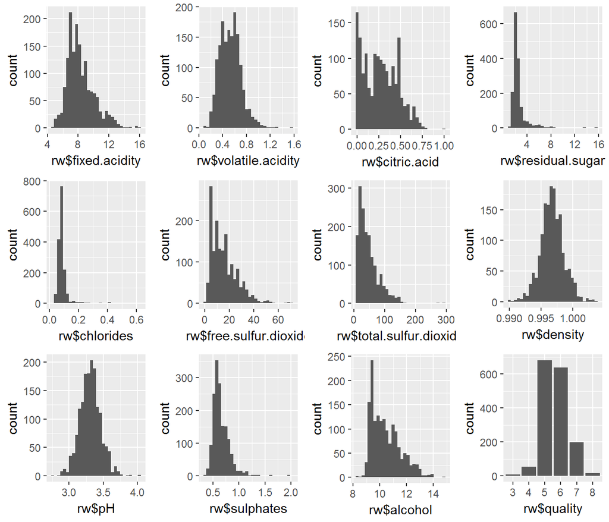

Here I made histograms of all the variables to see distribution of values.

```
##     bad average    good
##      63    1319     217
```

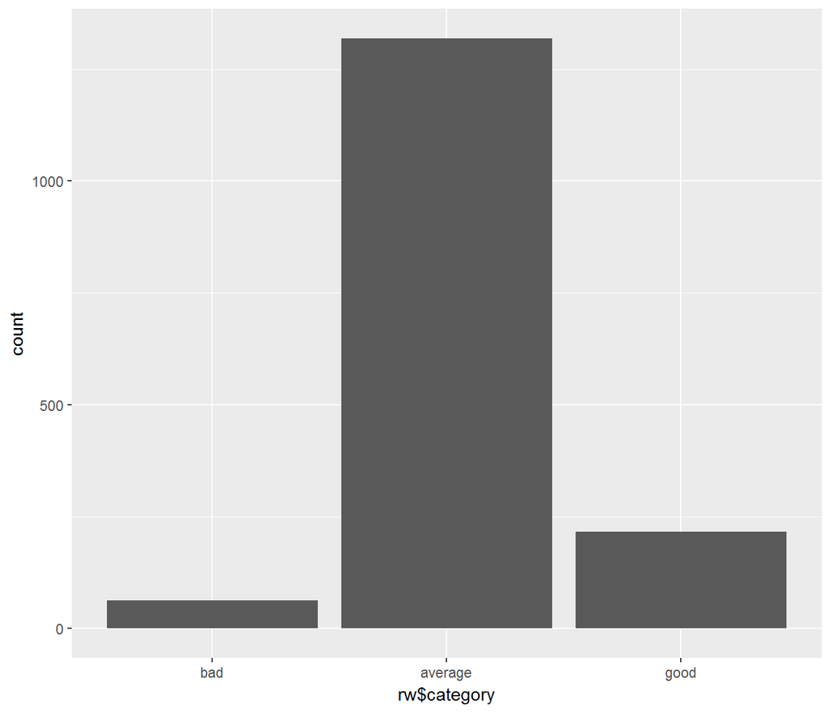

# Univariate Analysis:

What is the structure of your dataset?

There are 1599 observations of 13 numeric variables.

What is/are the main feature(s) of interest in your dataset?

Quality is the intresting variable to study in the red wine data set and how it is affected due to certain chemicals.

What other features in the dataset do you think will help support your investigation into your feature(s) of interest?

I think the acids present in the wine and the alcohol levels affects the quality of wine, here the volatile acidity, fixed acidity and citric acids and alcohol are the important features.

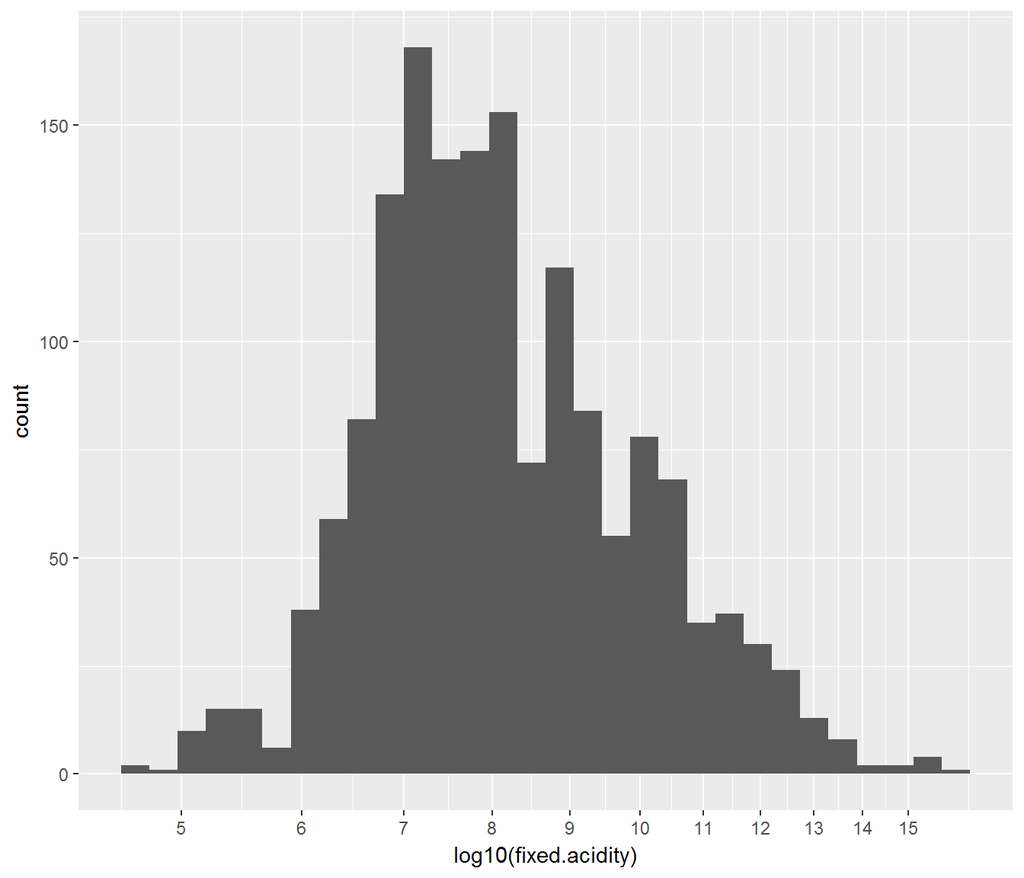

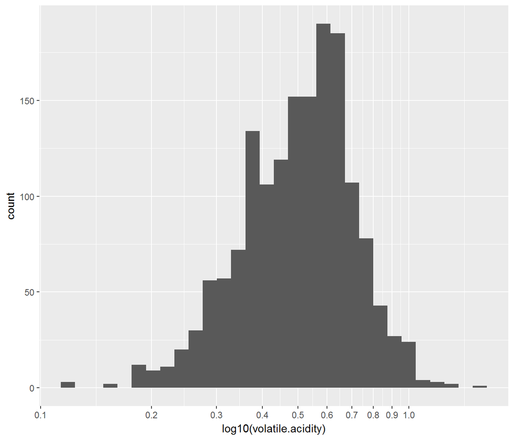

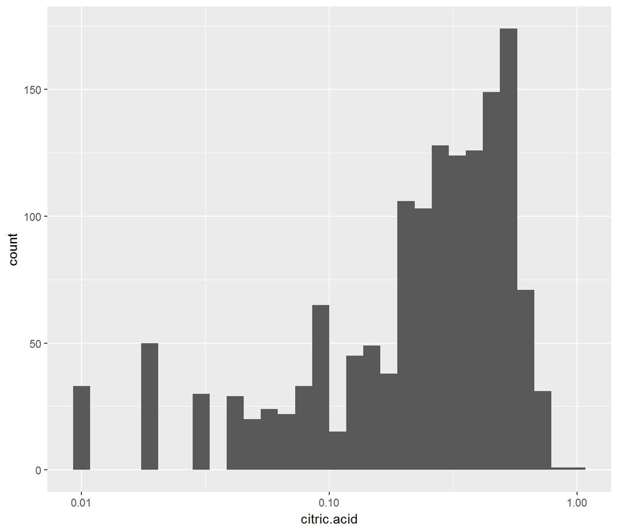

```
## [1] 132
```

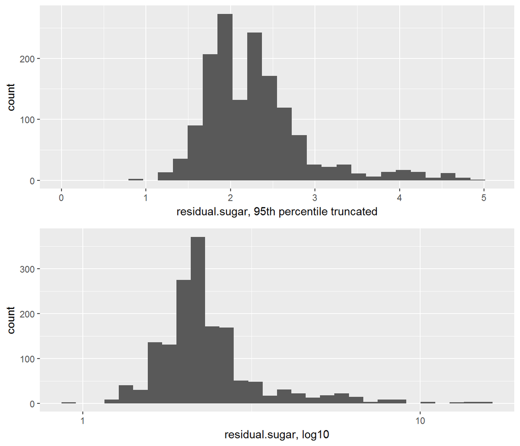

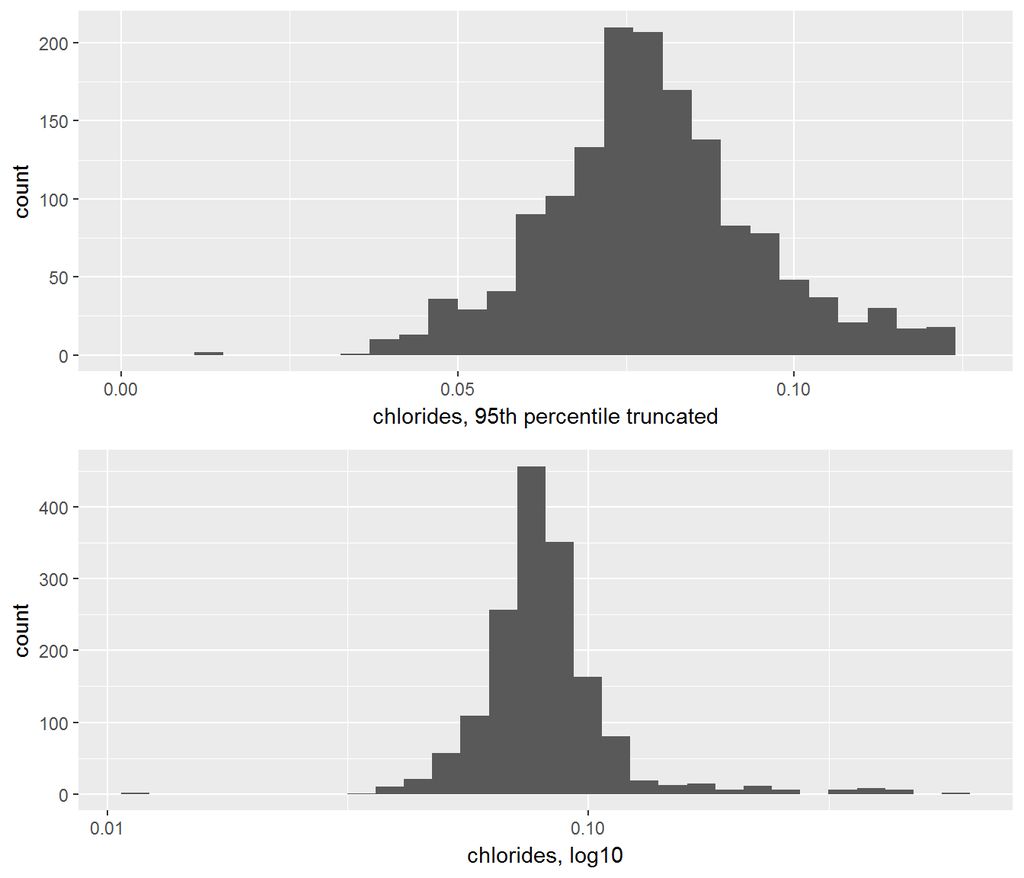

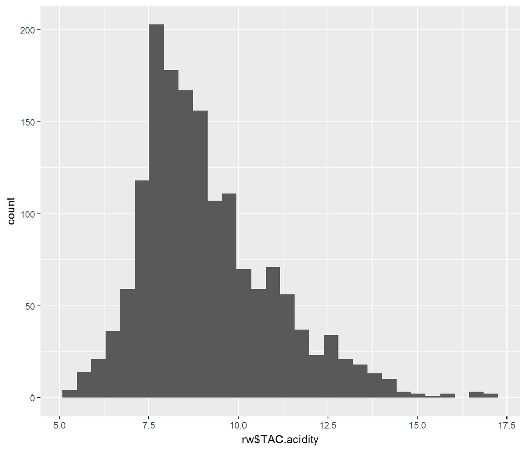

Did you create any new variables from existing variables in the dataset?

Yes, I created the ordered factor variable of quality i.e.“category”, for further analysis, also I will combine the three types of acids and create a variable called “TAC.acidity”.

Of the features you investigated, were there any unusual distributions? Did you perform any operations on the data to tidy, adjust, or change the form of the data? If so, why did you do this?

Most of the wines belong to average category as compared to very few in bad as well as in good. Fixed and volatile acidity, sulfur dioxides, sulphates, and alcohol seem to be long-tailed. It appears that density and pH are normally distributed, with few outliers. Qualitatively, residual sugar and chlorides have extreme outliers. I used log10 scale to see the distribution of the some of the variables.

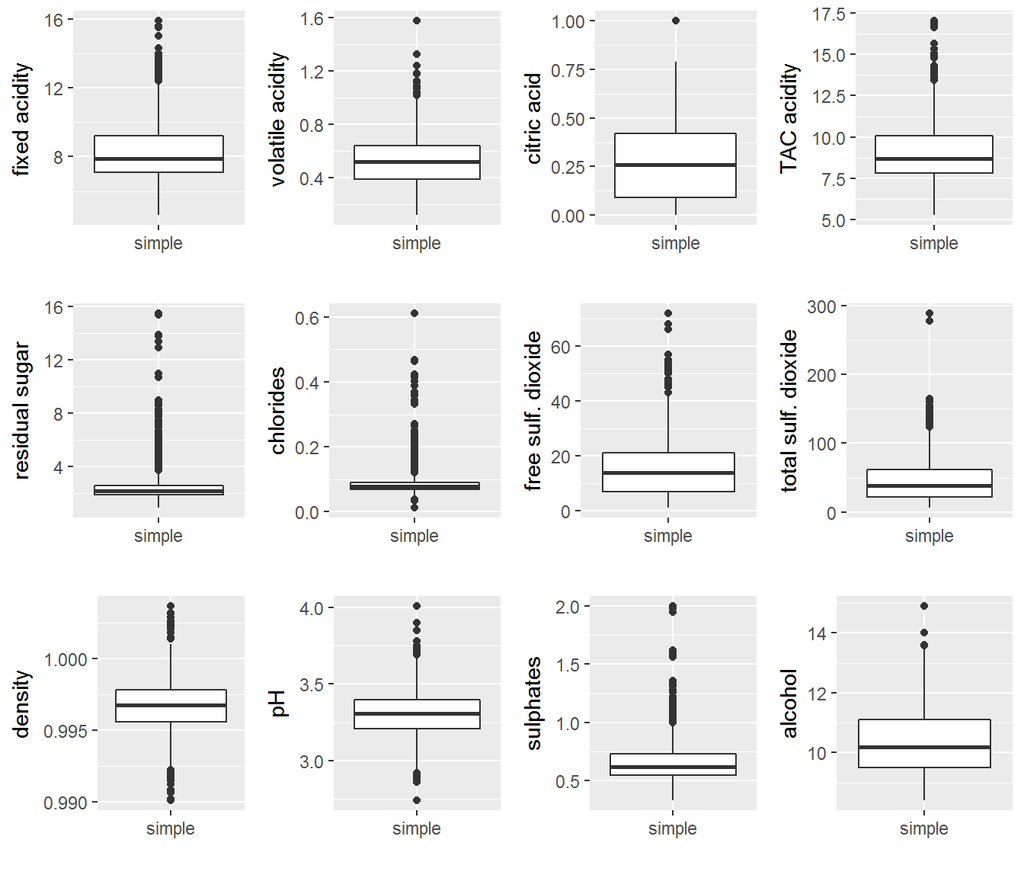

# Bivariate Plots and Analysis

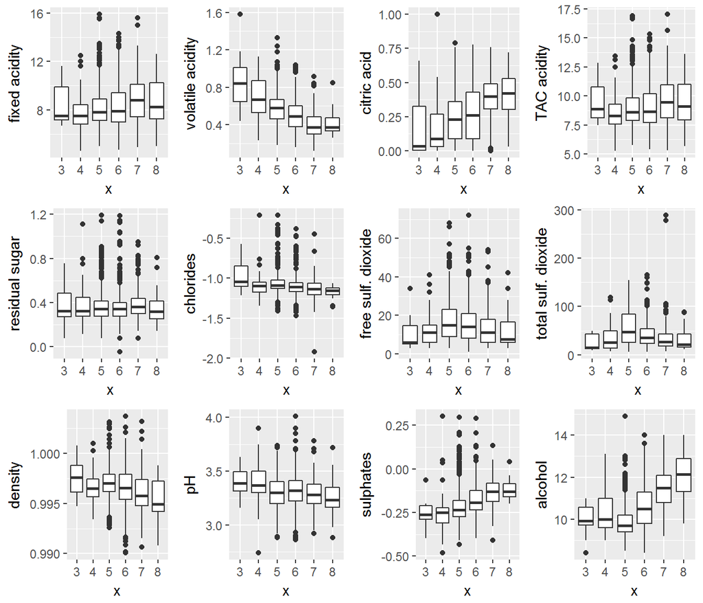

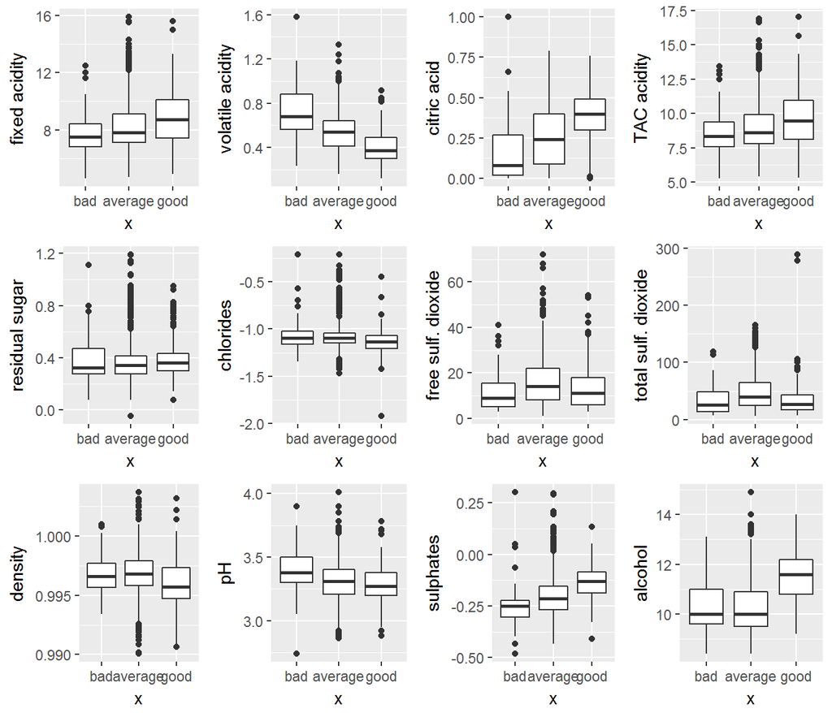

From exploring these plots, it seems that a ‘good’ wine generally has these trends: higher fixed acidity (tartaric acid) and citric acid, lower volatile acidity (acetic acid) lower pH (i.e. more acidic) higher sulphates higher alcohol to a lesser extend, lower chlorides and lower density Residual sugar and sulfur dioxides did not seem to have a dramatic impact on the quality or rating of the wines. Interestingly, it appears that different types of acid affect wine quality different; as such, TAC.acidity saw an attenuated trend, as the presence of volatile (acetic) acid accompanied decreased quality. By utilizing cor.test, I calculated the correlation for each of these variables against quality:

```
##        fixed.acidity     volatile.acidity          citric.acid
##           0.12405165          -0.39055778           0.22637251
##          TAC.acidity log10.residual.sugar      log10.chlordies
##           0.10375373           0.02353331          -0.17613996
##  free.sulfur.dioxide total.sulfur.dioxide              density
##          -0.05065606          -0.18510029          -0.17491923
##                   pH      log10.sulphates              alcohol
##          -0.05773139           0.30864193           0.47616632
```

Quantitatively, it appears that the following variables have relatively higher correlations to wine quality: alcohol sulphates (log10) volatile acidity citric acid Let’s see how these variables compare, plotted against each other and faceted by wine standard:

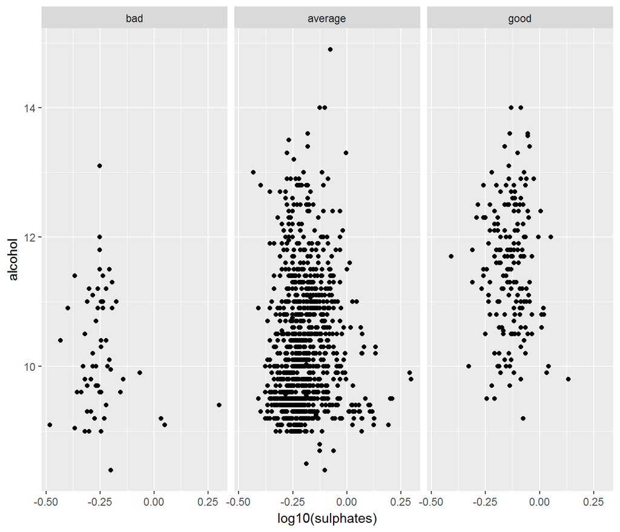

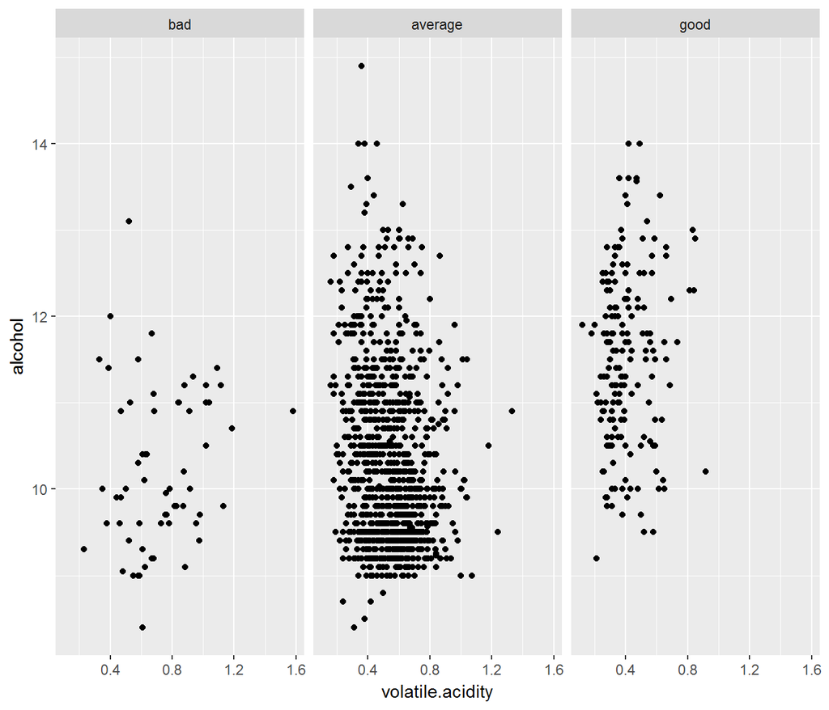

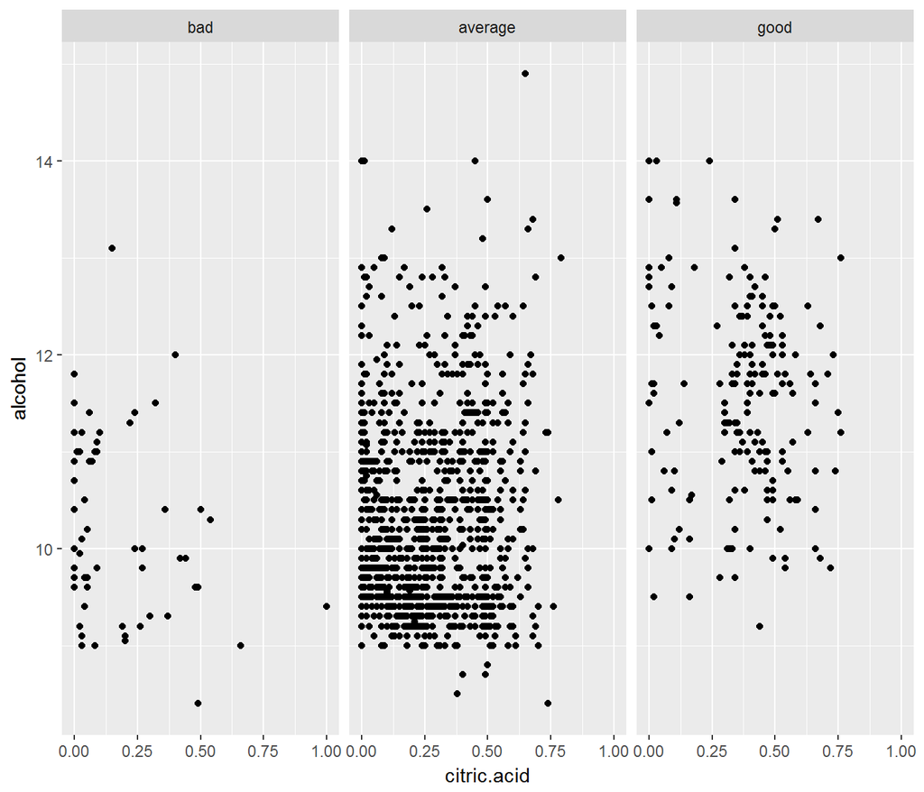

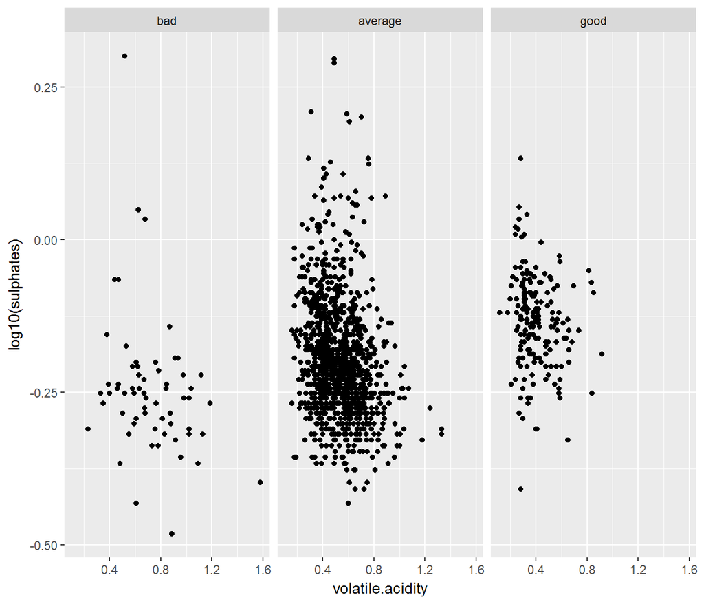

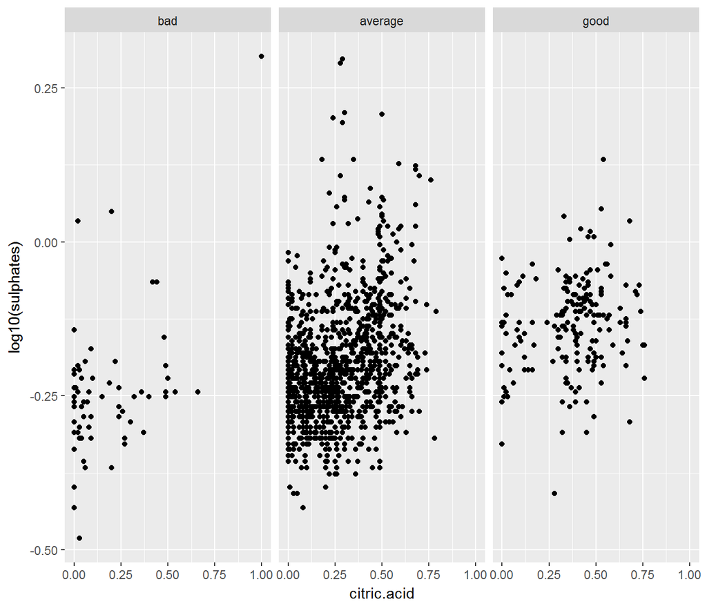

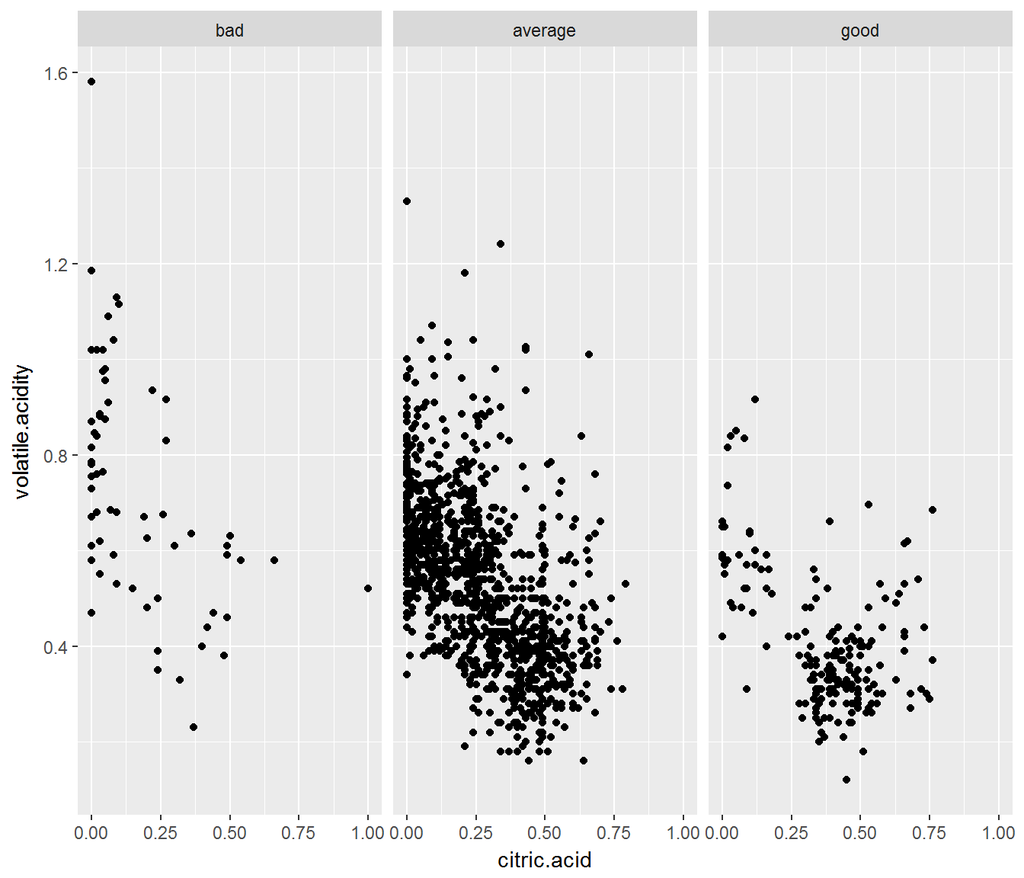

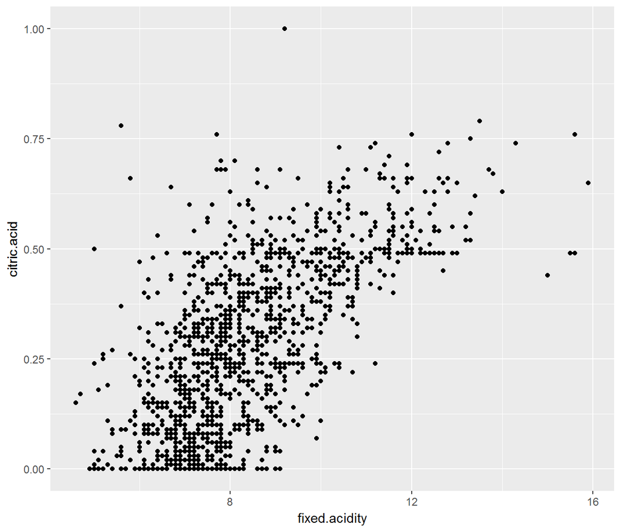

```
##
##  Pearson's product-moment correlation
##
## data:  rw$fixed.acidity and rw$citric.acid
## t = 36.234, df = 1597, p-value < 2.2e-16
## alternative hypothesis: true correlation is not equal to 0
## 95 percent confidence interval:
##  0.6438839 0.6977493
## sample estimates:
##       cor
## 0.6717034
```

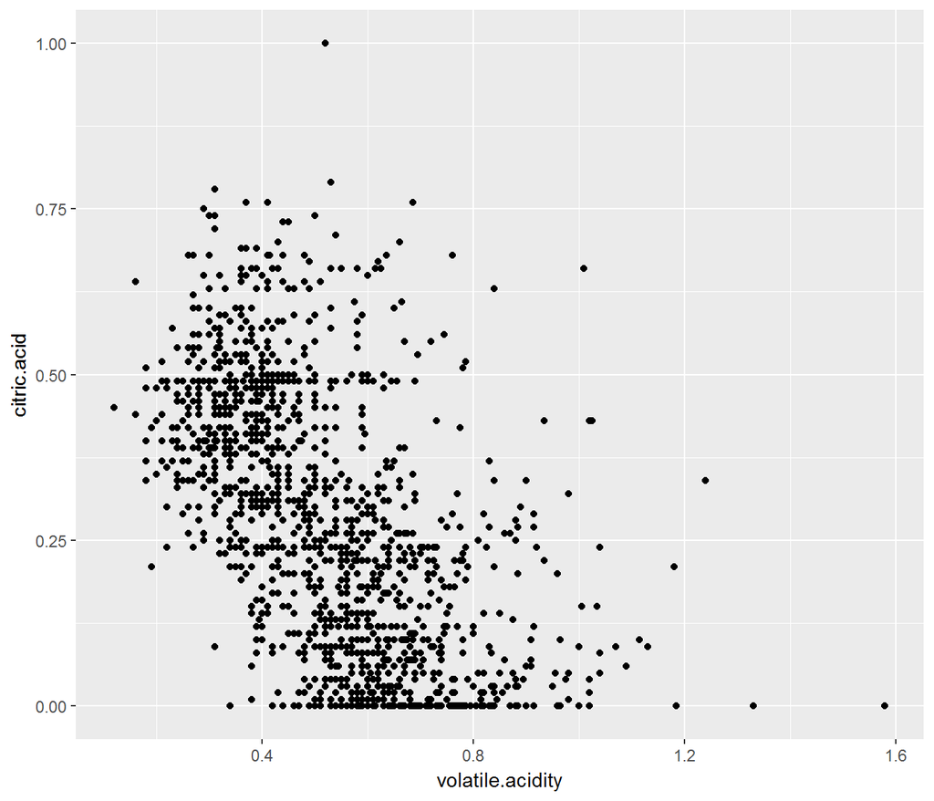

```
##
##  Pearson's product-moment correlation
##
## data:  rw$volatile.acidity and rw$citric.acid
## t = -26.489, df = 1597, p-value < 2.2e-16
## alternative hypothesis: true correlation is not equal to 0
## 95 percent confidence interval:
##  -0.5856550 -0.5174902
## sample estimates:
##        cor
## -0.5524957
```

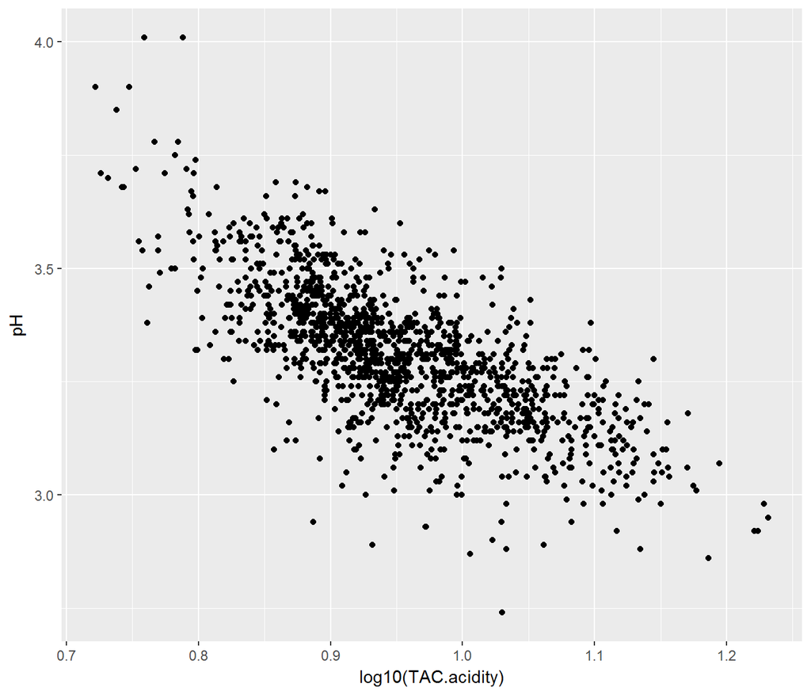

```
##
##  Pearson's product-moment correlation
##
## data:  log10(rw$TAC.acidity) and rw$pH
## t = -39.663, df = 1597, p-value < 2.2e-16
## alternative hypothesis: true correlation is not equal to 0
## 95 percent confidence interval:
##  -0.7283140 -0.6788653
## sample estimates:
##        cor
## -0.7044435
```

Most notably, base 10 logarithm TAC.acidity correlated very well with pH. This is certainly expected, as pH is essentially a measure of acidity. An interesting question to pose, using basic chemistry knowledge, is to ask what other components other than the measured acids are affecting pH. We can quantify this difference by building a predictive linear model, to predict pH based off of TAC.acidity and capture the % difference as a new variable.

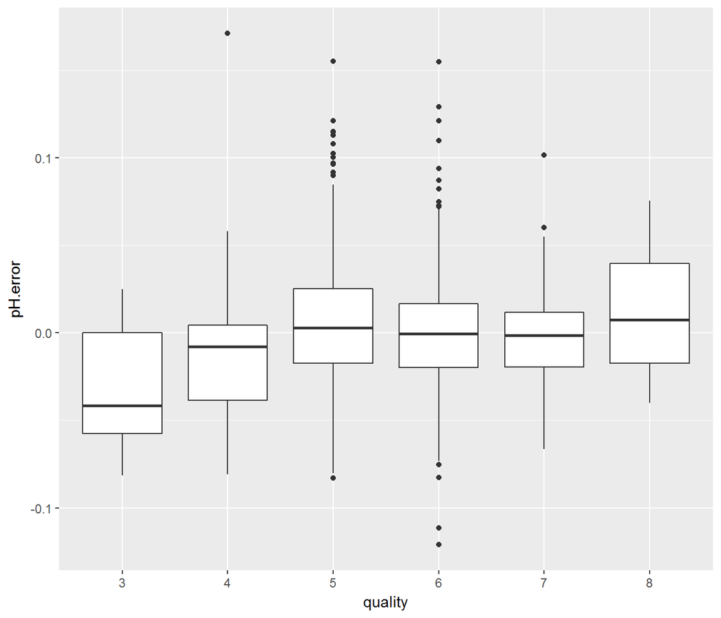

The median % error hovered at or near zero for most wine qualities. Notably, wines rated with a quality of 3 had large negative error. We can interpret this finding by saying that for many of the ‘bad’ wines, total acidity and citric acids were a worse predictor of pH. Simply put, it is likely that there were other components–possibly impurities–that changed and affected the pH. As annotated previously, I hypothesized that free.sulfur.dioxide and total.sulfur.dioxide were dependent on each other. Plotting this:

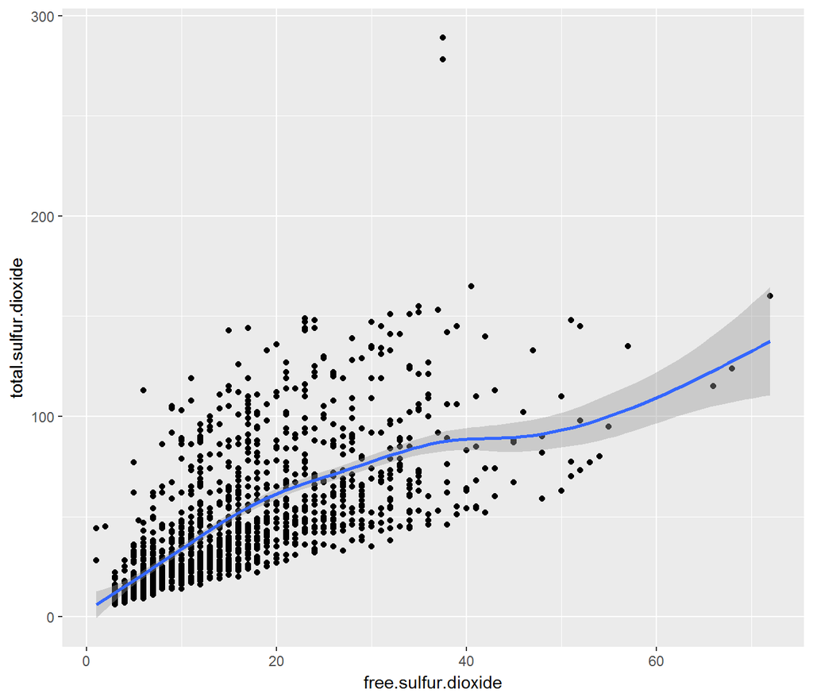

```
##
##  Pearson's product-moment correlation
##
## data:  rw$free.sulfur.dioxide and rw$total.sulfur.dioxide
## t = 35.84, df = 1597, p-value < 2.2e-16
## alternative hypothesis: true correlation is not equal to 0
## 95 percent confidence interval:
##  0.6395786 0.6939740
## sample estimates:
##       cor
## 0.6676665
```

It is clear that there is a very strong relationship between the two. Aside from TAC.acidity, this seemed to be the strongest bivariate relationship. Additionally, despite the telling name descriptions, the clear ‘floor’ on this graph hints that free.sulfur.dioxide is a subset of total.sulfur.dioxide.

# Multivariate Plots:

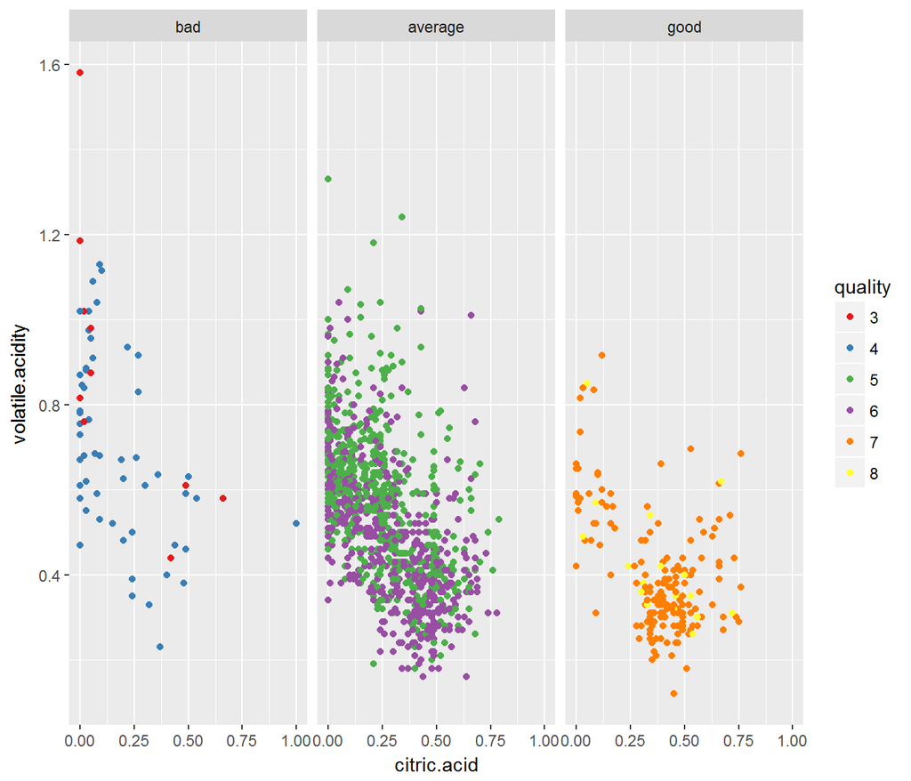

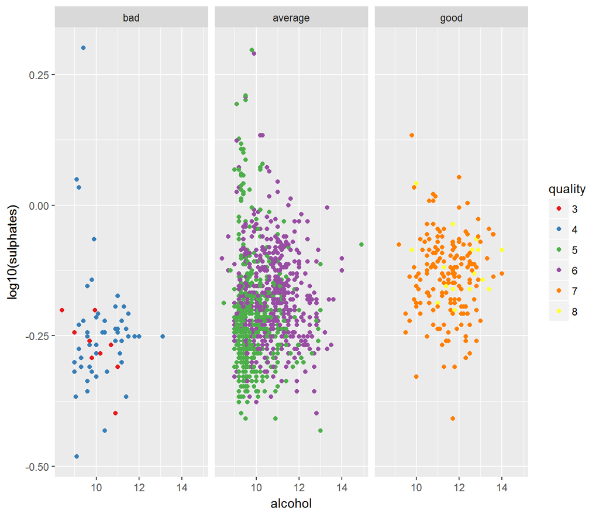

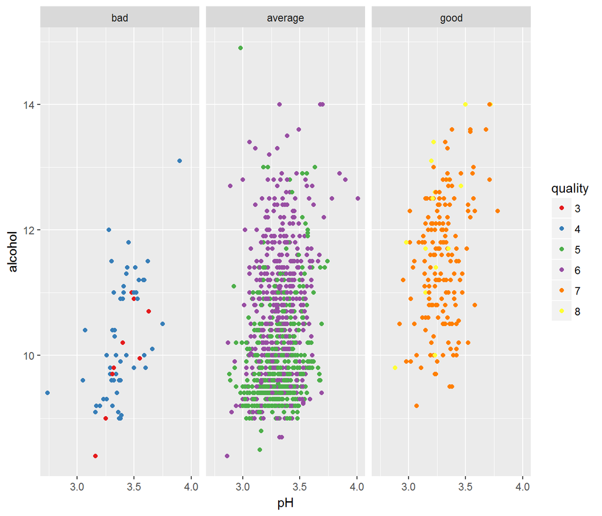

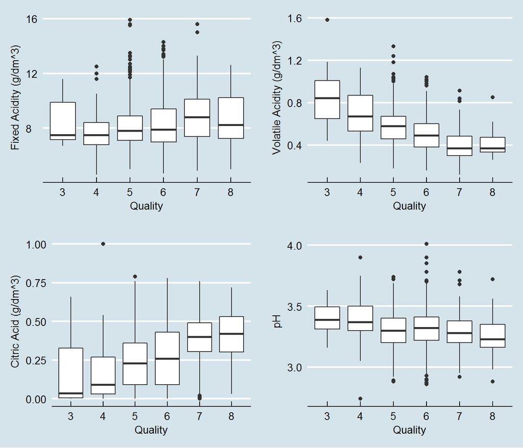

# Multivariate Analysis:

I primarily examined the 4 features which showed high correlation with quality. These scatterplots were a bit crowded, so I faceted by rating to illustrate the population differences between good wines, average wines, and bad wines. It’s clear that a higher citric acid and lower volatile acid contributes towards better wines. Likewise, better wines tended to have higher sulphates and alcohol content. Surprisingly, pH had very little visual impact on wine quality, and was shadowed by the larger impact of alcohol. Interestingly, this shows that what makes a good wine depends on the type of acids that are present. These subplots were created to demonstrate the effect of acidity and pH on wine quality. Generally, higher acidity (or lower pH) is seen in highly-rated wines. To caveat this, a presence of volatile acid negatively affected wine quality. Citric acidity had a high correlation with wine quality, while fixed acid had a smaller impact.

# Final Plots and Summary:

## Plot 1: Effect of acids on wine quality

[figure not shown]

## Plot 2: Effect of Alcohol on Wine Quality

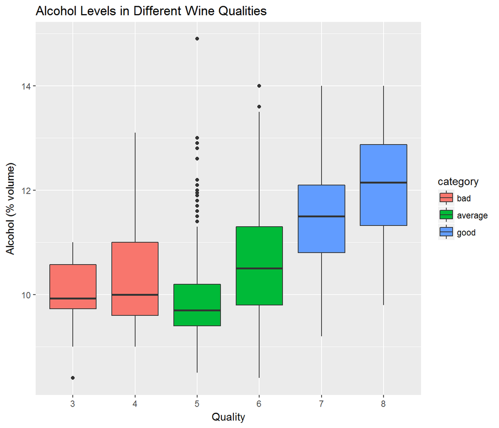

These boxplots demonstrate the effect of alcohol content on wine quality. Generally, higher alcohol content correlated with higher wine quality. However, as the outliers and intervals show, alchol content alone did not produce a higher quality.

## Plot 3: What makes good wines, good, and bad wines, bad?

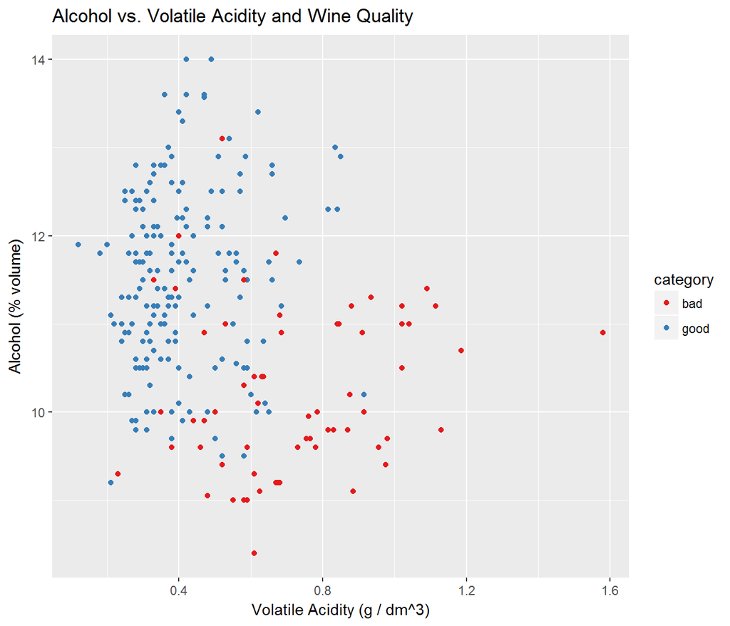

This is perhaps the most telling graph. I subsetted the data to remove the ‘average’ wines, or any wine with a category of 5 or 6. As the correlation tests show, wine quality was affected most strongly by alcohol and volatile acidity. While the boundaries are not as clear cut or modal, it’s apparent that high volatile acidity–with few exceptions–kept wine quality down. A combination of high alcohol content and low volatile acidity produced better wines.

# Reflection :

I started by looking at the individual distributions of the variables, trying to investigate each seperately.Out of the chemical varibles, the only one that stood out was the concentration of citric acid . First thing i noticed was the high number of wines that had no citric.acid at all. My initial thought was a data collection error, but upon researching the subject, I found out that citric acid is sometimes added to wines to boost overall acidity, so it makes sense that some wines would have none. Nonetheless this variable also showed a strange distribution with some peaks but showing an almost rectangular distribution specially in the 0-0.5 range. All of the other variables showed either an normal or long tailed looking distribution. Through this exploratory data analysis,I had many challenges while analyzing the chemical composition of all the variables and how those are related, but I was able to identify the key factors that determine and drive wine quality, mainly: alcohol content, sulphates, and acidity. Most confusing ones were the pH and the acids, but then after researching some websites on the internet I started getting the ideas about the variables and I started creating my analysis on the quality which is base of my project. The most promissing varibles were alcohol concentration, sulphates and the individual acid concentrations. My biggest challenge was to build the predictive model,for analysing the other factors which were affecting the pH other than the acids but with the help of example project and some websites, I was able to build it. It is important to note, however, that wine quality is ultimately a subjective measure. The graphs adequately illustrate the factors that make good wines ‘good’ and bad wines ‘bad’. Further study with inferential statistics could be done to quantitatively confirm these assertions.